# OldFaithfulGeyser

March 15, 2018

## 1. Summary

We provide interactive Shiny application based on data collected on YeallowStone Park Old Faithful Gyser.  
[Old Faithful Geyser](http://www.wildnatureimages.com/Old-Faithful-Geyser-Photos.htm)

This application show histograms of waiting time to next eruption, eruptions duration.  
Also allows to investigate relationship between eruption time and waiting time until next eruption.  
Here's the link to shiny app.  
[Old Faithful Geyser App](https://devdataproducts.shinyapps.io/DevDataProducts/)  
This application shows 3 interactive tabs:  
1. Waiting time histogram  
2. Eruption time histogram  
3. Linear regression between eruptions time and waiting time to next eruption,  
based on user selection of data points  
[github repository](https://github.com/jsternin/OldFaithfulGeyser)

## 3. Tab panel: Eruptions~waiting regression

Tab Eruptions-waiting time shows points in coordinates  
X-eruption time, Y- waiting time until next eruption.  
User can select (swipe) any subset of points and  
regression line will be interactively built showing  
Slope, Intersect and Ajusted Sum of Squares.  
Ajusted sum of suares is \(adjSumSq = 1-RSS/TSS\)  
where \(RSS = sum((data - fitted)^{2}\) \(TSS = sum((data - mean(data)^{2})\)  
Ajusted sum of suares shows percentage of data  
that model explains. Next slide shows regression  
line when all points are selected.

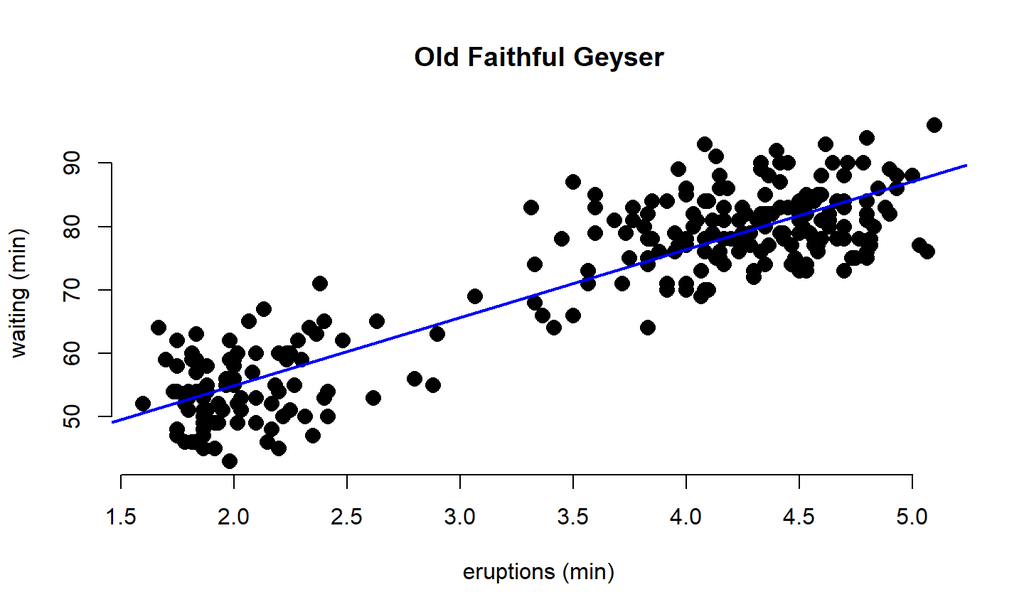

```
## [1] "Slope: 10.73 Intercept:33.47 Adj R squared: :0.811  "
```